# Разведочный анализ данных TripAdvisor об отелях

### Анализ доступных параметров отеля

Посмотрим на общую статистику по имеющимся параметрам отеля.

```
##    locationID        rankinList        awards          awardCategories
##  Min.   : 300676   Min.   :  1.00   Length:172         Length:172
##  1st Qu.: 478386   1st Qu.: 43.75   Class :character   Class :character
##  Median : 929144   Median : 86.50   Mode  :character   Mode  :character
##  Mean   :1376897   Mean   : 86.50
##  3rd Qu.:1582215   3rd Qu.:129.25
##  Max.   :7394507   Max.   :172.00
##
##      name               url                rating         reviews
##  Length:172         Length:172         Min.   : 0.00   Min.   :   0.0
##  Class :character   Class :character   1st Qu.:40.00   1st Qu.:  23.0
##  Mode  :character   Mode  :character   Median :45.00   Median : 259.0
##                                        Mean   :39.68   Mean   : 434.3
##                                        3rd Qu.:45.00   3rd Qu.: 690.2
##                                        Max.   :50.00   Max.   :3366.0
##
##   rating1Count     rating2Count    rating3Count     rating4Count
##  Min.   : 0.000   Min.   : 0.00   Min.   :  0.00   Min.   :  0.00
##  1st Qu.: 1.000   1st Qu.: 2.00   1st Qu.:  8.00   1st Qu.: 10.25
##  Median : 4.500   Median : 6.50   Median : 18.00   Median : 60.00
##  Mean   : 8.006   Mean   :12.01   Mean   : 30.92   Mean   :101.07
##  3rd Qu.:10.750   3rd Qu.:17.00   3rd Qu.: 40.00   3rd Qu.:147.75
##  Max.   :62.000   Max.   :88.00   Max.   :164.00   Max.   :572.00
##  NA's   :18       NA's   :18      NA's   :18       NA's   :18
##   rating5Count     familyReviewsCount coupleReviewsCount
##  Min.   :   0.00   Min.   :  0.00     Min.   :   1.00
##  1st Qu.:  13.25   1st Qu.:  5.00     1st Qu.:  21.75
##  Median : 197.50   Median : 40.00     Median : 209.50
##  Mean   : 332.26   Mean   : 73.01     Mean   : 324.69
##  3rd Qu.: 474.00   3rd Qu.:108.25     3rd Qu.: 490.25
##  Max.   :2533.00   Max.   :456.00     Max.   :2419.00
##  NA's   :18        NA's   :18         NA's   :18
##  singleReviewsCount businessReviewsCount locationRating   sleepRating
##  Min.   : 0.000     Min.   : 0.000       Min.   :20.00   Min.   :20.00
##  1st Qu.: 2.000     1st Qu.: 1.000       1st Qu.:45.00   1st Qu.:40.00
##  Median : 6.000     Median : 2.000       Median :45.00   Median :45.00
##  Mean   : 8.429     Mean   : 4.591       Mean   :45.65   Mean   :42.76
##  3rd Qu.:12.000     3rd Qu.: 5.000       3rd Qu.:50.00   3rd Qu.:45.00
##  Max.   :44.000     Max.   :97.000       Max.   :50.00   Max.   :50.00
##  NA's   :18         NA's   :18           NA's   :18      NA's   :18
##   roomsRating    serviceRating    valueRating    clenalinessRating
##  Min.   :20.00   Min.   :20.00   Min.   :15.00   Min.   :20.00
##  1st Qu.:40.00   1st Qu.:40.00   1st Qu.:40.00   1st Qu.:40.00
##  Median :45.00   Median :45.00   Median :40.00   Median :45.00
##  Mean   :42.86   Mean   :43.27   Mean   :40.98   Mean   :43.93
##  3rd Qu.:50.00   3rd Qu.:45.00   3rd Qu.:45.00   3rd Qu.:50.00
##  Max.   :50.00   Max.   :50.00   Max.   :50.00   Max.   :50.00
##  NA's   :18      NA's   :19      NA's   :19      NA's   :23
##  firstReviewID           class
##  Min.   : 12594850   Min.   :30.00
##  1st Qu.:230605220   1st Qu.:40.00
##  Median :249724239   Median :42.50
##  Mean   :231979462   Mean   :42.89
##  3rd Qu.:253136941   3rd Qu.:50.00
##  Max.   :257270445   Max.   :50.00
##  NA's   :13          NA's   :56
```

Видим большое количество отсутствующих значений (NA). Например, параметр отеля **rating1Count** означает количество отзывов, в которых отель получил суммарный рейтинг, равный 1 звезде. Отсутствие значения у этого параметра означает, что такой рейтинг не был присвоен ни в одном из отзывов. Логичным будет заменить отсутствующие значения у всех параметров, отражающих количество отзывов на 0.

Также у некоторых отелей отсутствует **рейтинг** по какой-либо из категорий, например, sleepRating - рейтинг качества сна, измеряется в звездах от 1 до 5. Однако, если ни в одном из отзывов отель не получил ни одной оценки по данному параметру, то он содержит пустое значение (NA). Логичным будет заменить отсутствующие значения рейтингов на 0.

Если отель не имеет категории, выраженной звездами, будем считать. что его категория равна “0 звезд”.

Рейтинг отеля может иметь дробное значение, например “4.5 звезды”. В исходных приведен умноженный на 10 рейтинг, т.е. в данном случае он записан ка “45”. Тоже самое касается категории (количества звезд отеля): “5 звезд” записано как “50”. Оставляем такую запись без изменений.

Посмотрим, от каких параметров зависит суммарный рейтинг отеля на Tripadvisor, вычисляемый на основе отзывов полльзователей.

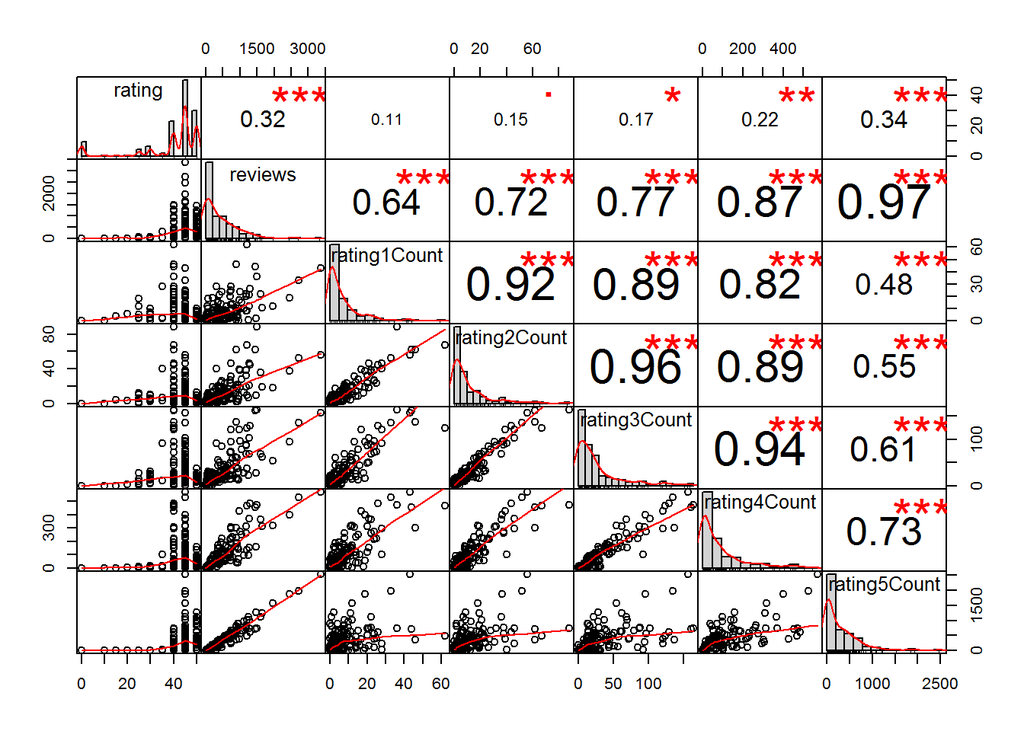

Из рисунка видим, что рейтинг (rating) отеля больше у отелей с большим количеством отзывов, а также видим, что чем больше у отлея отзывов с ценкой 5.0, тем выше его рейтинг. При этом связи между рейтингом отеля и количеством отзывов с оценкой 1.0 нет. Также видим, что количество оценок 1.0, 2.0, 3.0 и 4.0 очень сильно коррелируют между собой - коэффициент корреляции 0,8-0,96, т.е. чем больше у отеля оценок 1.0, тем больше оценок 4.0. Поведение количества наивысших оценок (5.0) отличается: корееляция с оценками 1-4 есть, но заметно ниже ~0,5-0,7. При этом есть очень сильная корреляция (0,97) с количеством отзывов, что означает, что пользователи пишут в основном отзывы с оценками 5.0

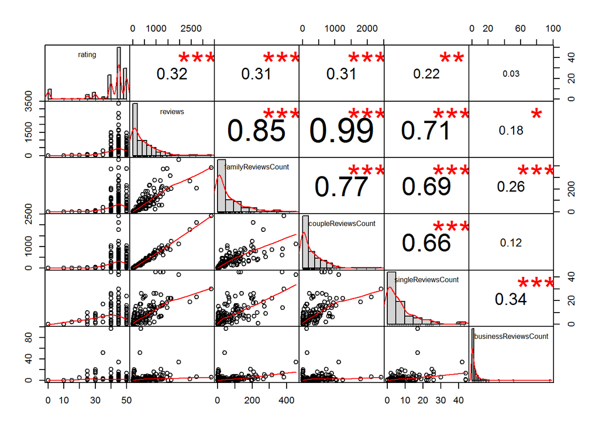

Из рисунка видим, что общее количество отзывов об отеле максимально сильно коррелирует с количеством отзывов пар (0,99), семей (0,85) и одиночных путешественников (0,71). Корреляция с отзывами бизнесменов практически отсутствует (0,18), что означает, что бизнесмены оставляют отзывы не о тех же отелях, что остальные категории путешественников. Также видим, что общее количество отзывов от бизнесменов (не более 100 об одном отеле) и одиночек (не более 50 отзывов) намного меньше, чем от семей (до 450) и пар (до 2500), что означает, что Мальдивы - место отдыха, а не бизнеса, и больше отдыха романтического и семейного, чем одинокого.

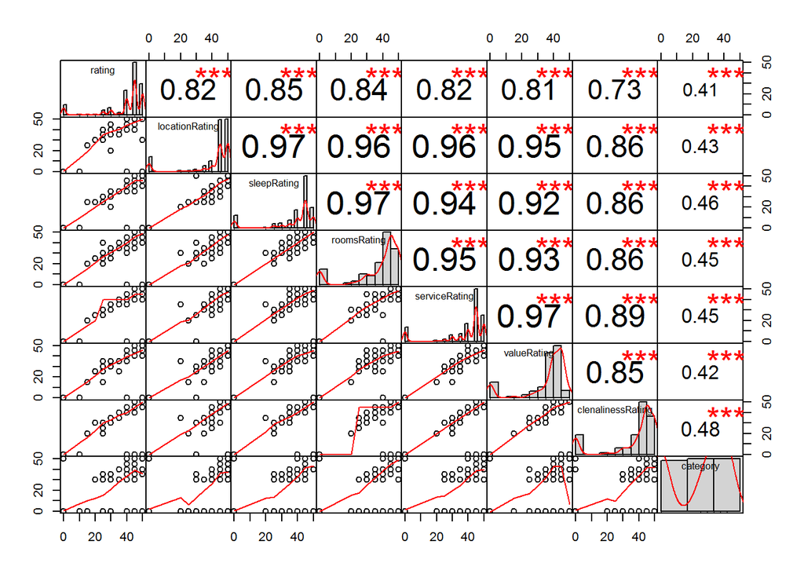

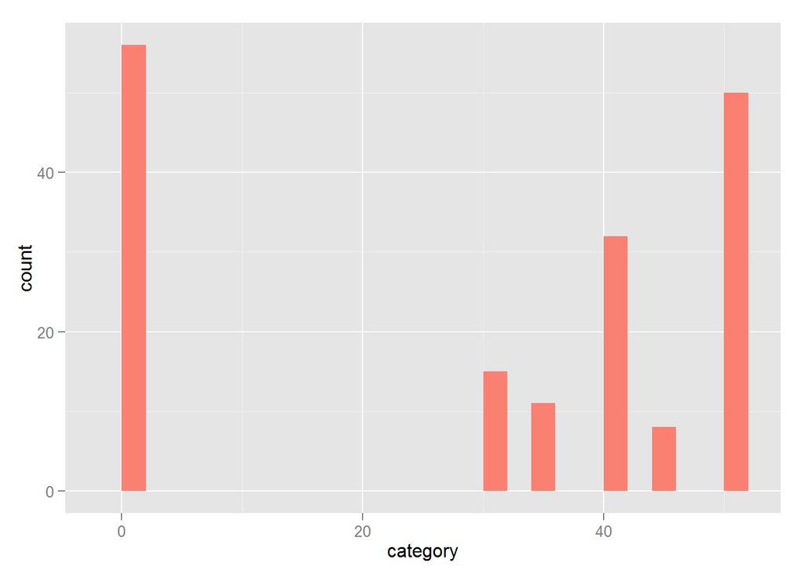

Из графика видим, что в регионе имеется достаточно большое количество отелей без звезд (категория равна 0). Проанализируем их отдельно:

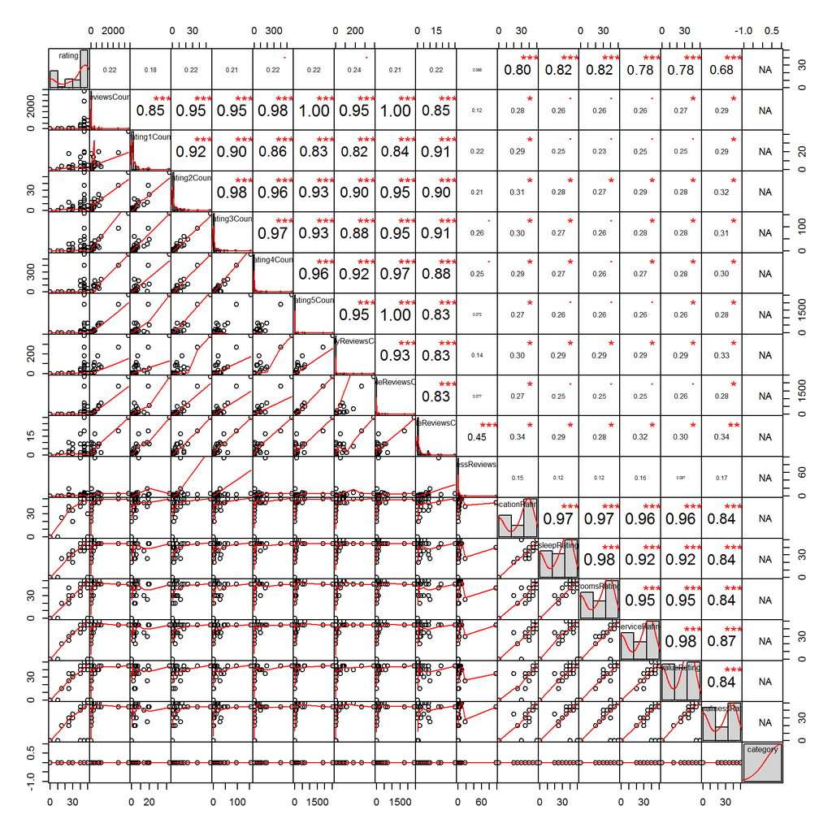

на рисунке видим примерно такую же картину, как и на предыдущих графиках, где рассматривали все отели вместе. Далее будем рассматривать отели без звезд (категория равна 0) вместе с остальными.

### Обработка параметров отеля

Все отели имеют разное количество отзывов, поэтому сравнивать их между собой по количеству отзывов будет некорректно. Вместо количественных параметров сформируем процентные, показывающее долю отзывов каждого типа от общего числа отзывов.

Проанализируем корреляции нормированных параметров.

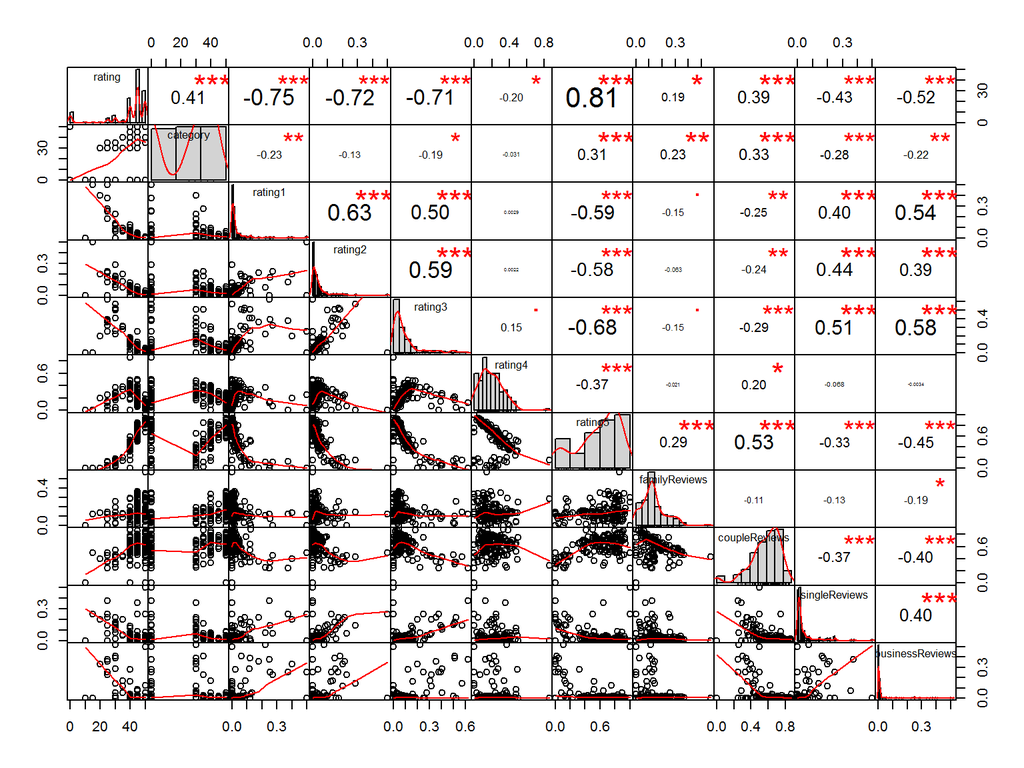

Рисунок сильно отличается от предыдущих и показывает заметно другую картину. По сути, видим, что нет смысла делать какие-либо выводы на основе анализа количественных показателей, таких как количество отзывов с рейтингом 1 (rating1Count), и стоит анализировать только долевые параметры отеля.  
Из рисунка видим следующее (слева-направо, сверху-вниз):

- Общий рейтинг выше у отелей с большим количеством звезд - очевидно.
- Общий рейтинг отеля сильно положительно связан с оценками в 5 баллов (0.81), другими словами, чем выша доля оценок “5 баллов” среди всех оценок отеля, тем выше его общий рейтинг, что логично. Общий рейтинг сильно отрицательно связан с оценками в 1-3 балла и, что любопытно, не сильно коррелирует с оценками “4 балла” (-0,20).
- Общий рейтинг отеля умеренно положительно коррелирует с количеством отзывов от пар (0,39) и слабо коррелирует с количеством отзывов от семей (0,19). Пары гораздо чаще пишут отзывы, чем семьи, поэтому их влияние на рейтинг больше.
- Общий рейтинг отеля отрицательно коррелирует с количеством отзывов от одиноких (-0,43) бизнес (-0,52) путешественников. Эти категории туристов пишут отзывы редко и, если пишут, то чаще отрицательные - корреляция 0,39-0,58 между частотой отзывов 1-3 балла и частотой отзывов от одиноких и путешественников в деловой поездке.
- Интересна связь между категорией (количеством звезд) отеля и частотой отзывов “5 баллов”: **отели без категории получают оценку “5 баллов” в среднем так же часто, как отели категории 5 звезд**.
- Оценки в 1-3 балла коррелируют между собой (0,5-0,6), что означает, что чем больше оценок 1 балл, тем больше оценок в 2 и 3 балла и наоборот.
- Чем чаще отель получает оценку “4 балла”, тем реже он получает оценку “5 баллов” (-0,37).
- Путешественники на Мальдивы разделились на 3 категории: семейные, пары и одиночки с бизнесменами.
  - Семейные пишут не часто (20-30% отзывов) и дают разнонаправленные отзывы.
  - Пары пишут часто (~70% отзывов) и дают в основном положительные отзывы.
  - Одиночки и бизнесмены пишут очень редко (<10%) и дают в основном негативные отзывы.

### Зависимость “интересности отеля” от других параметров

Попробуем визуально обнаружить взаимосвязь инетересующих нас отелей от их параметров. Интересные отели имеют class=1, не интересные class=0.

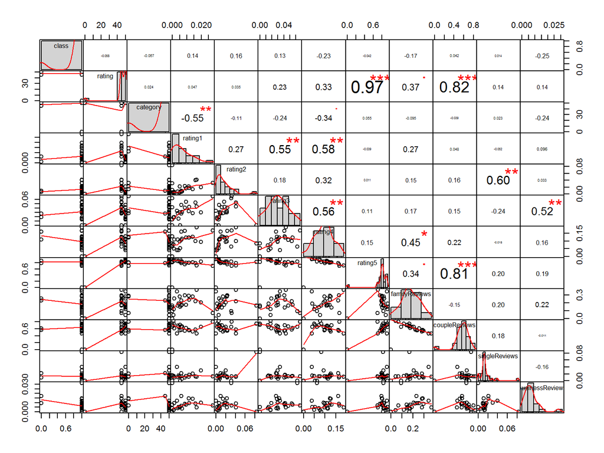

Из рисунка видим недостаточное количество классифицированных отелей (отсутствие звездочек в перовй строке).

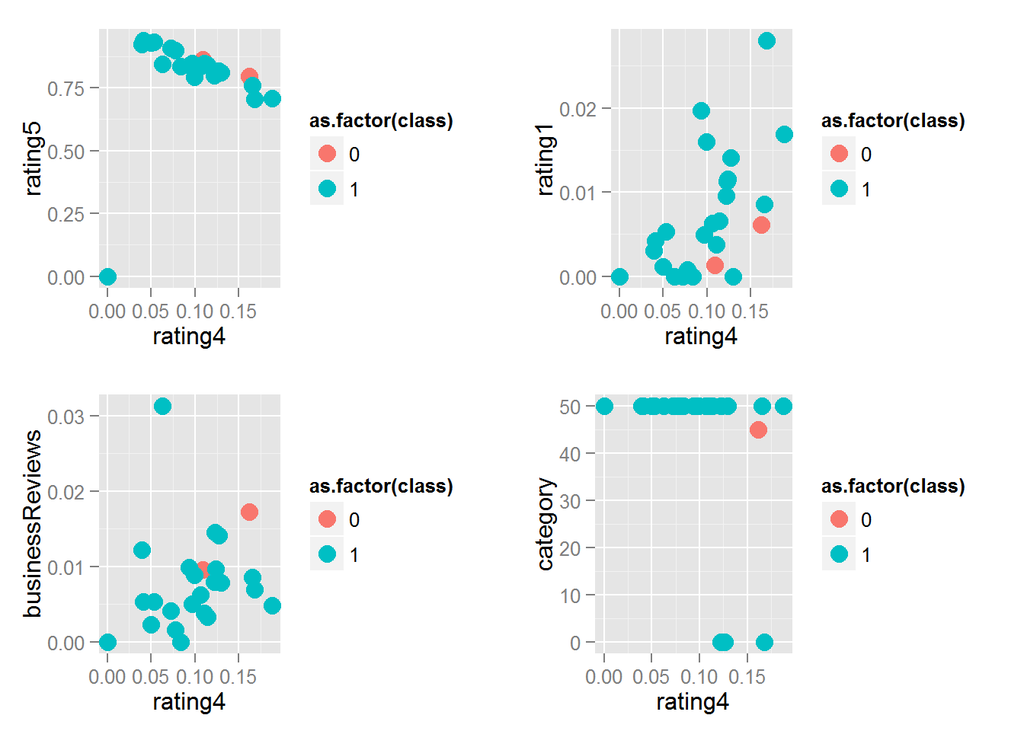

Проведем нормализацию и масштабирование. Выделим методом главных компонет 2 ГП и отобразим их на графике с раскрасской по классу.